# Spatial Analysis and Data Exploration in History and Archaeology

Uine Kailamäki

04/2021

This is my course page for the R exercises in the Spatial Analysis and Data Exploration in History and Archaeology course, University of Helsinki, lectured by Eljas Oksanen in the Spring of 2021.

**How to create a course page:**

You need to have R, RStudio and Git installed and Git linked to your Rstudio before this step.

1. Create a new GitHub repository
2. Open RStudio and create a new project by selecting: “File” - “New Project” - “Version Control” - “Git” and paste the web URL in the “Repository URL” box.
3. Create a web page on GitHub:
1. Go back to the GitHub repository.
2. Open “Settings” and scroll to “GitHub Pages”. From “Source” select “master branch”.
3. Now your course diary web page is online at github_username.github.io/repository_name

# 1: Introduction to R and SADE

In importing the .csv data to R there was a problem with importing European style .csv in which data is separated with ; instead of comma, and decimals are displayed with commas instead of dots. This was resolved by adding [sep=“;”, dec=“,”] when importing the data. I did also need to define the margin size for plots in order to display the results, but otherwise the exercise didn’t pose much difficulty.

## Importing and exploring data

```r
# I tested if the file is readable and if my path is correct:
file.exists("~/R/SADE/week1/axes.csv")
```

```
## [1] TRUE
```

```r
# Importing the data
setwd("~/R/SADE/week1")
axes <- read.csv(file="axes.csv", header=TRUE, sep=";", dec=",")
class(axes)
```

```
## [1] "data.frame"
```

```r
head(axes)
```

```
##   km_number find_type length width thickness weight       x      y
## 1     32039   kirveet  120.0  40.0        40  420.0 6987601 559225
## 2     33070   kirveet   91.0  50.0        25  331.0 7204072 587496
## 3     35902   kirveet  197.0  75.0        37  620.0 7638696 492759
## 4     39149   kirveet  193.0  82.0        45 1016.0 6941672 467565
## 5     39178   kirveet  174.0  41.0        84  759.8 6802153 328646
## 6     39452   kirveet   99.5  53.5        30  248.1 6748437 371160
```

```r
summary(axes)
```

```
##    km_number      find_type             length          width
##  Min.   :32039   Length:16          Min.   : 55.0   Min.   : 40.00
##  1st Qu.:39171   Class :character   1st Qu.:110.4   1st Qu.: 54.62
##  Median :39599   Mode  :character   Median :143.0   Median : 70.50
##  Mean   :38635                      Mean   :136.8   Mean   : 75.97
##  3rd Qu.:40106                      3rd Qu.:163.5   3rd Qu.: 92.25
##  Max.   :40334                      Max.   :197.0   Max.   :151.00
##
##    thickness      weight             x                 y
##  Min.   : 9   Min.   :  88.1   Min.   :6705920   Min.   :328646
##  1st Qu.:29   1st Qu.: 317.5   1st Qu.:6746623   1st Qu.:364874
##  Median :37   Median : 466.9   Median :6872906   Median :469289
##  Mean   :36   Mean   : 501.4   Mean   :6969577   Mean   :468313
##  3rd Qu.:40   3rd Qu.: 652.5   3rd Qu.:7201614   3rd Qu.:577979
##  Max.   :84   Max.   :1016.0   Max.   :7638696   Max.   :587496
##  NA's   :3
```

```r
summary(axes$weight)
```

```
##    Min. 1st Qu.  Median    Mean 3rd Qu.    Max.
##    88.1   317.5   466.9   501.4   652.5  1016.0
```

```r
summary(axes$length)
```

```
##    Min. 1st Qu.  Median    Mean 3rd Qu.    Max.
##    55.0   110.4   143.0   136.8   163.5   197.0
```

```r
sd(axes$weight)
```

```
## [1] 277.1391
```

```r
sd(axes$thickness, na.rm=T)
```

```
## [1] 17.46425
```

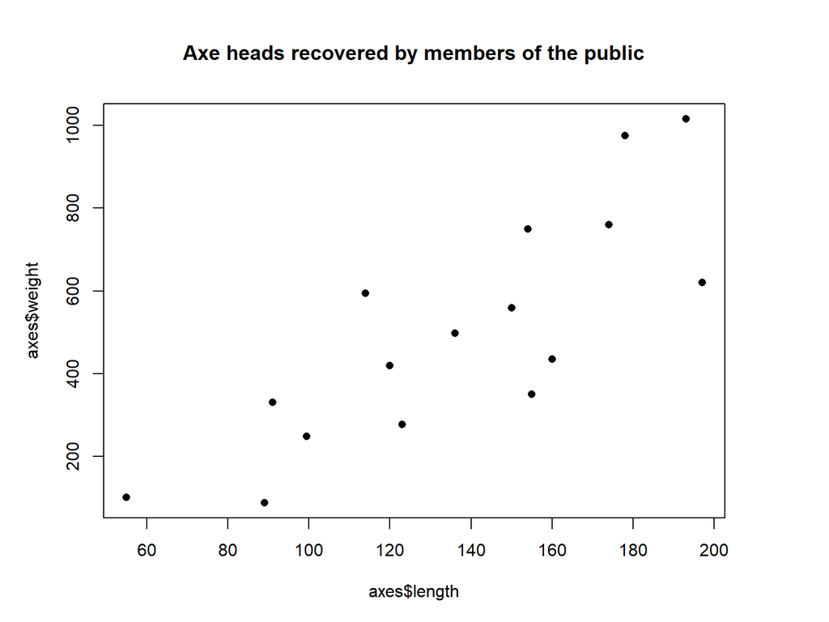

```r
# Plotting length vs weight
par(mai=c(1,1,1,1))
plot(x=axes$length, y=axes$weight, col="black", pch=16, main="Axe heads recovered by members of the public")
```

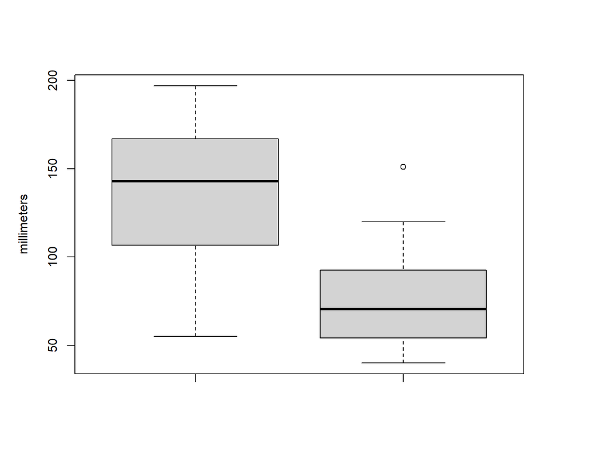

```r
# Boxplot: Axe length and width
boxplot(axes$length, axes$width, ylab="millimeters")
```

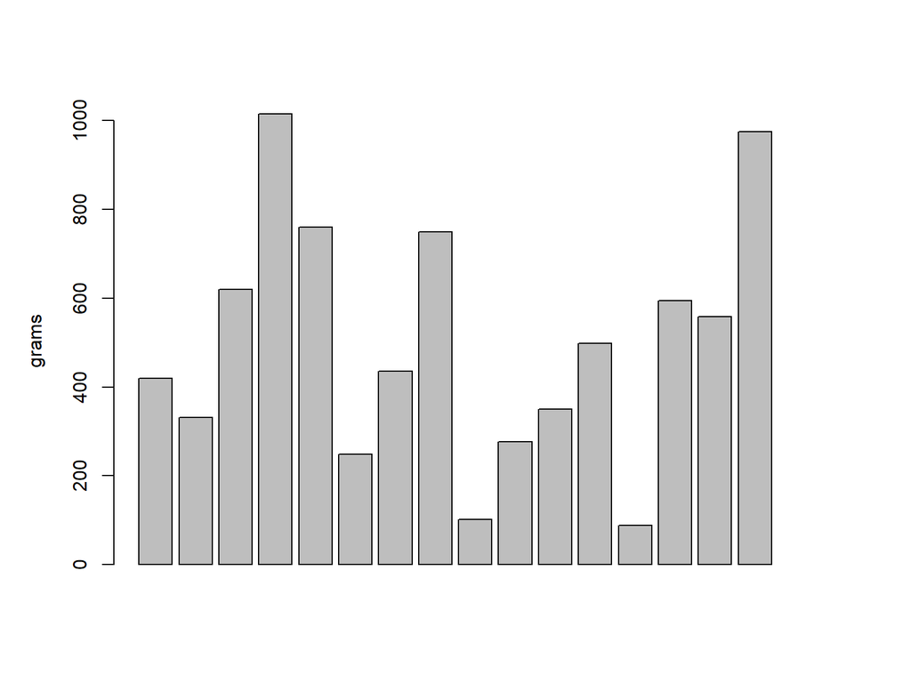

```r
# Barplot: Axe weight, no sorting
barplot(axes$weight, ylab="grams")
```

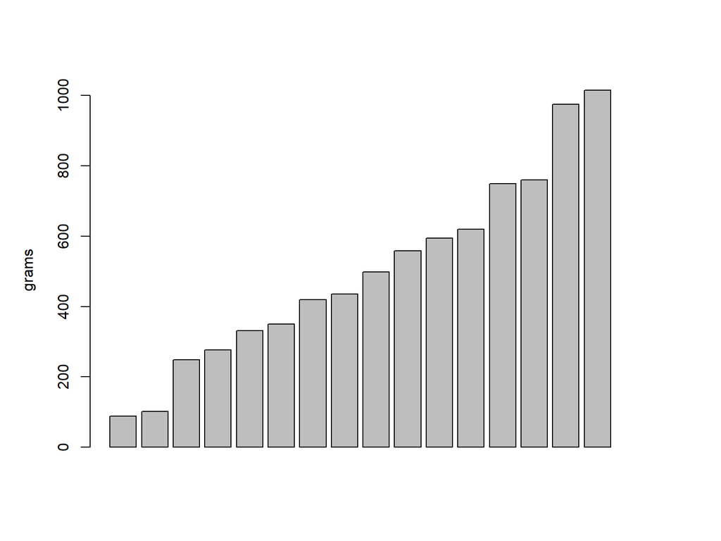

```r
# Barplot: Axe weight, sorted
barplot(sort(axes$weight), ylab="grams")
```

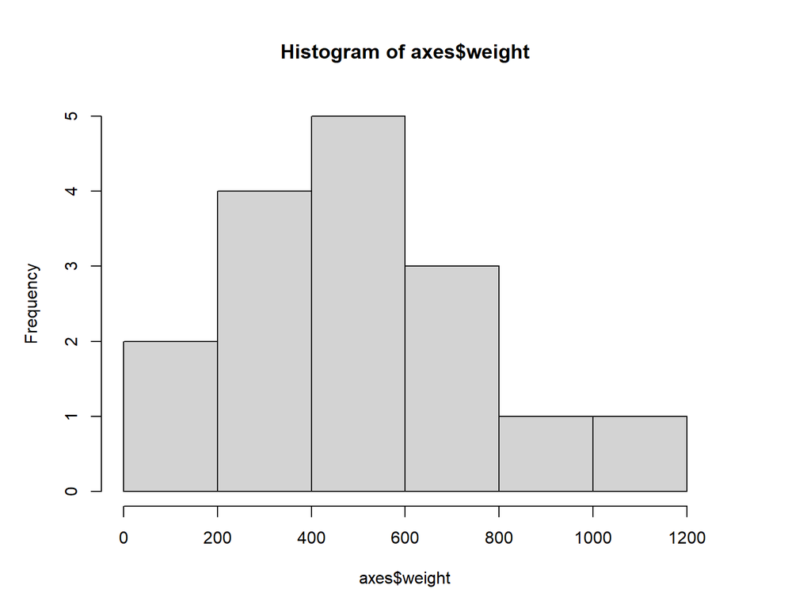

```r
# Histogram: Axe weight, default
hist(axes$weight)
```

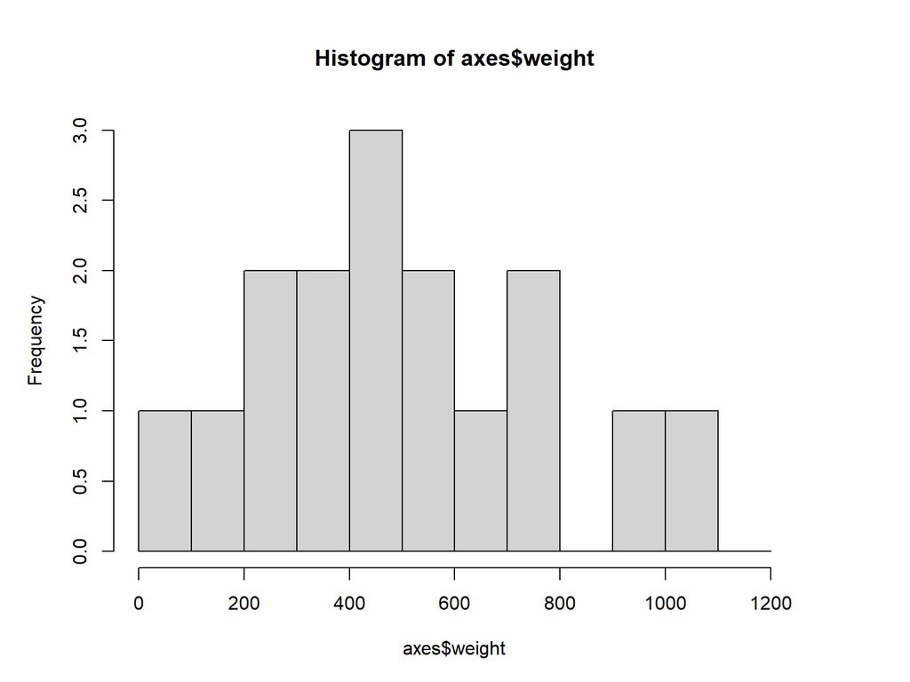

```r
# Histogram: Axe weight, breaks defined
hist(axes$weight, breaks=seq(0, 1200, 100))
```

```r
# Histogram: Combination
# Note: This works in R, but not in the knitted html page
dev.new(device=pdf, height=6, width=12)
par(mfrow=c(1,2), mai=c(1,1,1,1))
barplot(sort(axes$weight), ylab="grams", names.arg = c(axes$km_number), las=3)
hist(axes$weight)
```

## Plotting maps and spatial data

```r
# Necessary libraries + Finland ESRI Shapefile
library(rgdal)
library(raster)

fin <- readOGR(dsn="finland", layer="finland_valtakunta_simpler")
# Summary of Finland ESRI Shapefile
summary(fin)
```

```
## Object of class SpatialPolygonsDataFrame
## Coordinates:
##          min       max
## x   83725.35  732881.9
## y 6637635.87 7776440.6
## Is projected: TRUE
## proj4string :
## [+proj=utm +zone=35 +ellps=GRS80 +towgs84=0,0,0,0,0,0,0 +units=m
## +no_defs]
## Data attributes:
##     GML_ID            NATCODE            NAMEFIN            NAMESWE
##  Length:1           Length:1           Length:1           Length:1
##  Class :character   Class :character   Class :character   Class :character
##  Mode  :character   Mode  :character   Mode  :character   Mode  :character
```

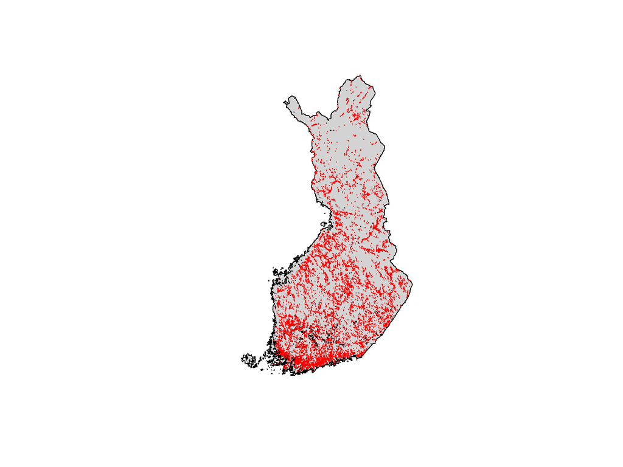

```r
# Plotting the data with monuments from .csv file
plot(fin, col="lightgrey")
monu <- read.csv(file="monuments_fha.csv", header=TRUE, sep=",")
coordinates(monu) <- ~X+Y
crs(monu) <- crs(proj4string(fin))
points(monu, pch=19, cex=0.1)
points(monu[monu$period == "stone age", ], pch=19, cex=0.1, col="red")
```

# 2: Point Pattern Analysis

## Point Densities

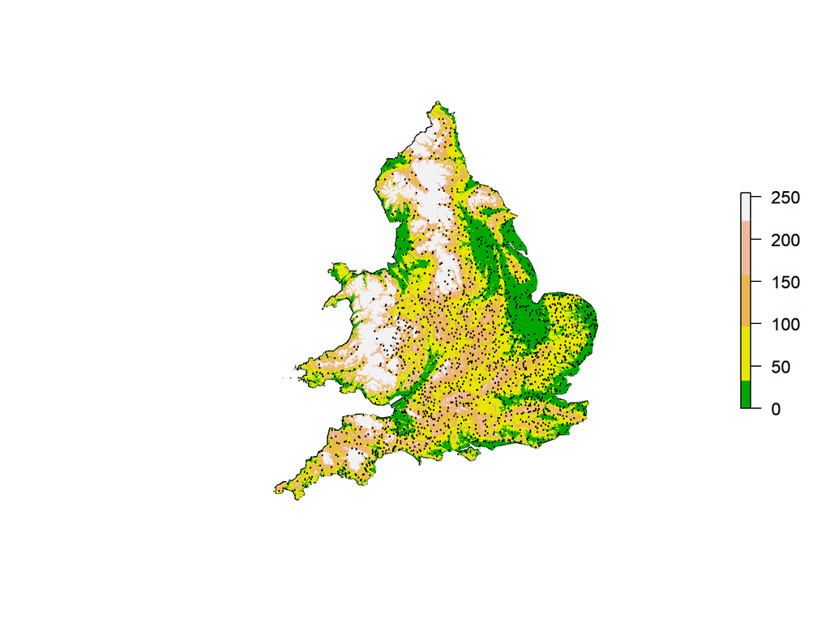

```r
# Importing the data
# Info about readOGR function: ?readOGR
library(rgdal)
library(raster)
library(spatstat)
library(maptools)

setwd("~/R/SADE/week2")
polyg <- readOGR(dsn="englandwales", layer="engwales_simple")
# Digital Elevation Model (DEM) taken from NASA’s Shuttle Radar Topography Mission data
dem <- raster("dem/engwales_dem.tif")
plot(polyg)
plot(dem, add=T)

# Change the color scheme to more intuitive one
plot(dem, add=T, col=terrain.colors(5))

# Loading medieval market sites from Samantha Letters’s (2002) Gazetteer of Markets and Fairs in England and Wales to 1516.
markets <- readOGR(dsn="markets1334", layer="markets1334")
points(markets, pch=19, cex=0.2)
```

```r
class(markets)
```

```
## [1] "SpatialPointsDataFrame"
## attr(,"package")
## [1] "sp"
```

```r
head(markets, n=10)
```

```
##     ID     MODNAME         COUNTY DEFYR BOROUGH VAL_1334 by1200
## 1   28  CANTERBURY           KENT   600       1     0.00      1
## 2    7      LONDON      MIDDLESEX   650       1 11000.00      1
## 3   34        YORK      YORKSHIRE   700       1  1620.00      1
## 4   32 SOUTHAMPTON      HAMPSHIRE   750       1   511.17      1
## 5   43   ROCHESTER           KENT   821       1     0.00      1
## 6   24   WORCESTER WORCESTERSHIRE   899       1   300.00      1
## 7    8 WALLINGFORD      BERKSHIRE   900       1    96.24      1
## 8   57      EXETER          DEVON   900       1   366.17      1
## 9  119     HALWELL          DEVON   900       1    13.50      1
## 10  29     LYDFORD          DEVON   900       1    11.67      1
```

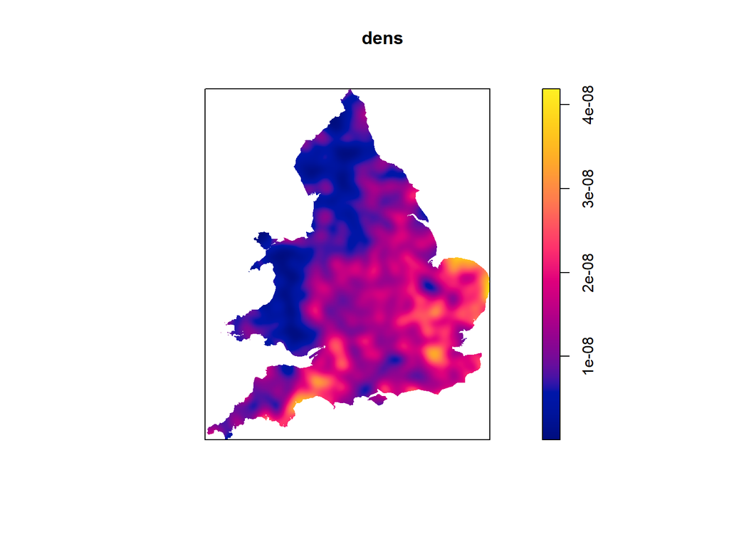

```r
# Manipulating the data:

# Lets make sure that the two have the same coordinate reference system (CRS) by taking the polygon’s CRS and applying it to the markets.
markets <- spTransform(markets, CRS(proj4string(polyg)))

# Subsetting the markets within the polygon's area to drop out those that fall outside of its borders
markets <- markets[polyg, ]

# Markets are events rather than places - let's save the data that contains duplicates as "market_events" and then remove duplicates from "markets"
market_events <- markets
markets <- remove.duplicates(markets)

# Creating spastat object from markets
sp_markets <- as.ppp(coordinates(markets), as.owin(polyg))

# Kernel Density Estimate (KDE)
dens <- density(sp_markets, sigma=10000, edge=TRUE, eps=500)
plot(dens)
```

```r
# Computation to determine an “optimal” bandwidth (sigma)
bw.diggle(sp_markets)
```

```
##   sigma
## 18971.5
```

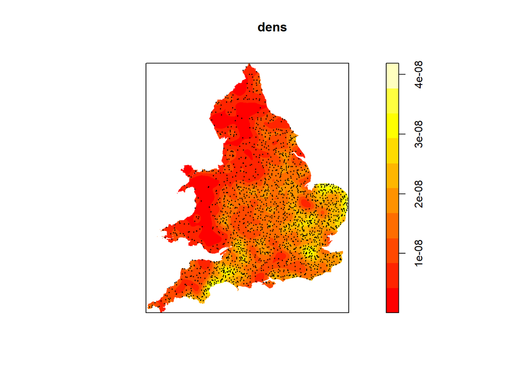

```r
# Adjusting color scheme and adding markets as points
plot(dens, col=heat.colors(10))
points(markets, pch=19, cex=0.2)
```

```r
# Investigating data for attributes that might have overtly strong impact
head(markets, n=20)
```

```
##     ID      MODNAME         COUNTY DEFYR BOROUGH VAL_1334 by1200
## 1   28   CANTERBURY           KENT   600       1     0.00      1
## 2    7       LONDON      MIDDLESEX   650       1 11000.00      1
## 3   34         YORK      YORKSHIRE   700       1  1620.00      1
## 4   32  SOUTHAMPTON      HAMPSHIRE   750       1   511.17      1
## 5   43    ROCHESTER           KENT   821       1     0.00      1
## 6   24    WORCESTER WORCESTERSHIRE   899       1   300.00      1
## 7    8  WALLINGFORD      BERKSHIRE   900       1    96.24      1
## 8   57       EXETER          DEVON   900       1   366.17      1
## 9  119      HALWELL          DEVON   900       1    13.50      1
## 10  29      LYDFORD          DEVON   900       1    11.67      1
## 11  72       PILTON          DEVON   900       1    10.00      1
## 12  46     BRIDPORT         DORSET   900       1    99.71      1
## 13  12  SHAFTESBURY         DORSET   900       1   200.00      1
## 14  50      WAREHAM         DORSET   900       1    63.50      1
## 15  17 CHRISTCHURCH      HAMPSHIRE   900       1    39.75      1
## 16  37  PORTCHESTER      HAMPSHIRE   900       1   119.01      1
## 17  16   WINCHESTER      HAMPSHIRE   900       1   515.17      1
## 18  33     AXBRIDGE       SOMERSET   900       1    45.00      1
## 19  36         BATH       SOMERSET   900       1   133.33      1
## 20  92     LANGPORT       SOMERSET   900       1    40.00      1
```

```r
# We find out that mean value has very big spread (up to £11,000)
summary(markets$VAL_1334)
```

```
##     Min.  1st Qu.   Median     Mean  3rd Qu.     Max.
##    -1.00     0.00    40.00    70.86    83.92 11000.00
```

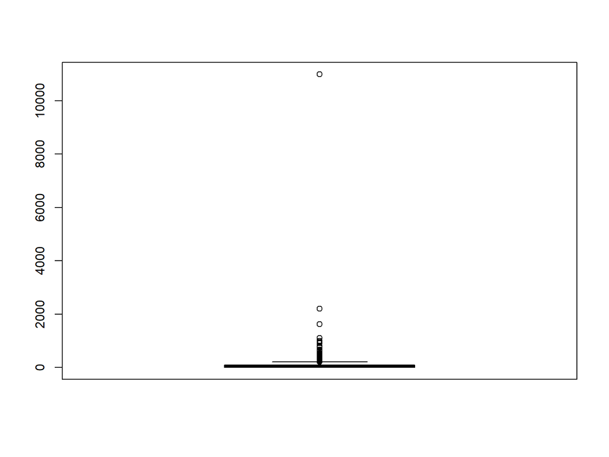

```r
# The wealth of London is statistical outlier and hides the weaker patterns in comparison
boxplot(markets$VAL_1334)
```

```r
# boxplot.stats gives us the lower whisker or minimum, the interquartile range of the middle (the second and fourth values), the median (third value) and the upper whisker or maximum.
boxplot.stats(markets$VAL_1334)
```

```
## $stats
## [1]  -1.000   0.000  40.000  83.915 205.000
##
## $n
## [1] 1947
##
## $conf
## [1] 36.99521 43.00479
##
## $out
##  [1] 11000.00  1620.00   511.17   300.00   366.17   515.17   220.00   800.00
##  [9]   300.00   261.38   358.83   370.50   540.75  1000.00   946.00   913.92
## [17]   604.54   265.44   270.00   466.09   645.25   292.50   227.36   382.88
## [25]  2200.00   280.50   360.00   293.06  1000.00   249.06   349.00   250.00
## [33]   242.50   266.67   210.00   245.75   600.30   390.12   213.19   270.00
## [41]   226.52   244.12   211.62   500.00   268.97   750.00   266.63   255.00
## [49]   333.33   240.52   255.00   262.30   266.63   330.00   409.50   260.00
## [57]   270.00   232.50   232.88   412.13   235.00   300.00   315.00   341.30
## [65]   750.08   398.15   357.61   232.50   221.25   285.00   270.00  1100.00
## [73]   211.04   210.00   495.00   375.00   250.00   225.00   210.00   480.00
## [81]   228.81   257.16   232.50   247.50   532.50   225.00   333.33   450.00
## [89]   450.00   225.00   400.65   315.00   240.00   220.75   247.42   412.50
## [97]   675.00
```

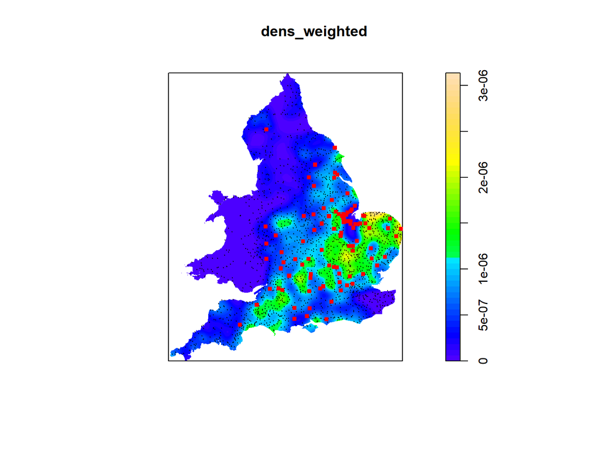

```r
# Subset to get rid of the high outliers to illustrate "weaker" patterns, original data is saved as markets_backup
markets_backup <- markets

markets_major <- subset(markets, VAL_1334 > 205)
markets <- subset(markets, VAL_1334 < 205)
sp_markets <- as.ppp(coordinates(markets),as.owin(polyg))

# Recalclulating KDE
dens_weighted <- density(sp_markets, sigma=10000,
weights=markets$VAL_1334, edge=TRUE, eps=500)
plot(dens_weighted, col=topo.colors(50))
points(markets, pch=19, cex=0.1)
points(markets_major, pch=15, cex=0.7, col="red")
```

## Relative risk surface

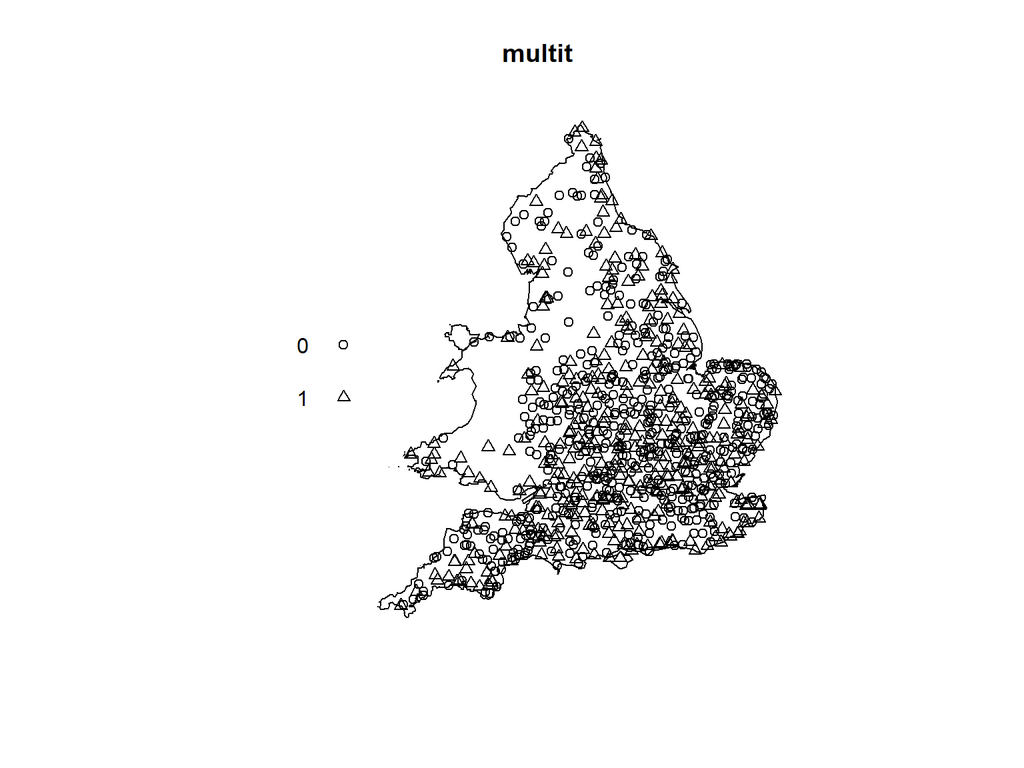

```r
# Setting up
markets <- subset(markets_backup, DEFYR<1251)
sp_markets <- as.ppp(coordinates(markets),as.owin(polyg))

# Subsetting data
earlier <- as.ppp(coordinates(markets[markets$by1200=="1",]),as.owin(polyg))
later <- as.ppp(coordinates(markets[markets$by1200=="0",]),as.owin(polyg))
multit <- sp_markets
marks(multit) <- as.factor(markets$by1200)

# Plotting the new multitype object
plot(multit)
```

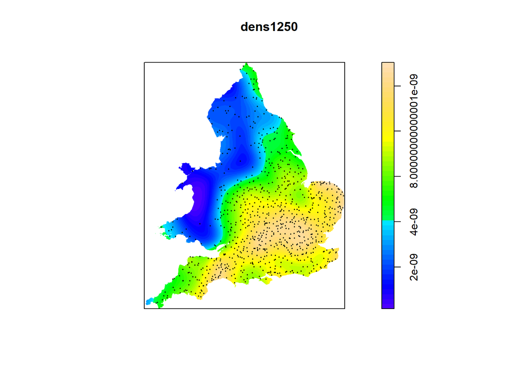

```r
# Density estimate of all the markets by 1250
dens1250 <- density(sp_markets, sigma=25000, edge=TRUE,
eps=500)
plot(dens1250, col=topo.colors(50))
points(markets, pch=19, cex=0.2)
```

```r
# Creating relative risk surface that contrasts earlier markets to those founded later

rrs <- relrisk(multit, sigma=25000, edge=TRUE, eps=500)
rrs[as.matrix(dens1250)<(0.000000001)] <- NA
dev.new(device=pdf, height=6, width=6)
plot(polyg)
plot(rrs, col=rev(topo.colors(50)), add=T)
plot(multit, cex=0.3, add=T)

# Plotting side by side still doesn't work in the webpage version... Might need to find other solutions for that!
```

## Nearest Neighbour

```r
# Distances between market sites and their closest neighbours
nndist(sp_markets)
```

```
##   [1]  3560.8988   761.5773 11681.1814 12067.3112  6325.3458  2701.8512
##   [7]   806.2258 10022.4747  5658.6217 10673.7997   806.2258 13928.3883
##  [13] 11092.3397  6685.0580 12567.4182  3275.6679 11360.0176  2690.7248
##  [19]  8237.7181  7060.4532  8202.4387  7723.3412   761.5773  2920.6164
##  [25]  5885.5756  9762.1719 10478.5495  2002.4984  7021.3959  7140.0280
##  [31]  4712.7487 11720.0683  1131.3708  3807.8866  9100.5494  5787.0545
##  [37]  9420.1911  7125.3070 11562.4392  8417.2442  9501.5788  9264.9879
##  [43]  7416.8727 12465.1514 10218.1212  9425.4973  3605.5513 14712.2398
##  [49] 11260.9946 14090.0674  7864.4771  3492.8498 15781.3181  9167.8787
##  [55] 10791.2001  4410.2154  9025.5194  7186.7934 14327.9447  7102.1124
##  [61] 12745.5875 10332.4731  6224.1465  6573.4314   509.9020   509.9020
##  [67]   806.2258  3757.6588 10720.0746  4494.4410 12149.8971  9827.0036
##  [73] 10107.9177  8134.4945  1220.6556  7723.3412   943.3981  3244.9961
##  [79]  7467.2619  4632.4939  4775.9816 10176.9347  2915.4759  5557.8773
##  [85]  4904.0799  6854.1958  3966.1064 14489.9965  7496.6659  1878.8294
```

[output cut: 133 more lines]

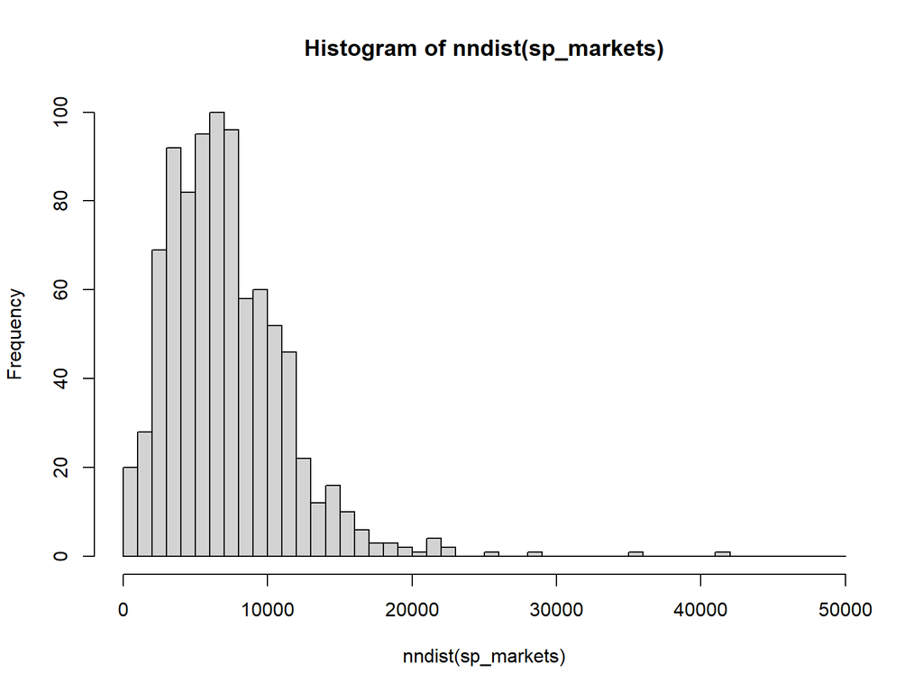

```r
# Visualizing the data and taking the mean
hist(nndist(sp_markets), breaks=seq(0, 50000, 1000))
```

```r
mean(nndist(sp_markets))
```

```
## [1] 7152.382
```

```r
# Clark and Evans test:
# R value of 1.08 tells the sites are slightly dispersed, and p << 0.05 tells us that the result is statistically significant
clarkevans.test(sp_markets, corrections="none")
```

```
##
##  Clark-Evans test
##  No edge correction
##  Z-test
##
## data:  sp_markets
## R = 1.0819, p-value = 3.206e-06
## alternative hypothesis: two-sided
```

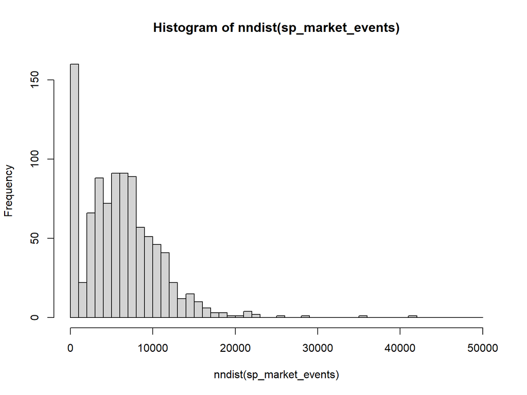

```r
# Calling back the "markets as events" data from earlier, creating a subset of those that were recorded before 1250
# R value of 0.96 tells us that the data is slightly clustered
market_events1250 <- subset(market_events, DEFYR<1251)
sp_market_events <-
as.ppp(coordinates(market_events1250),as.owin(polyg))
hist(nndist(sp_market_events), breaks=seq(0, 50000, 1000))
```

```r
mean(nndist(sp_market_events))
```

```
## [1] 6117.172
```

```r
clarkevans.test(sp_market_events, corrections="none")
```

```
##
##  Clark-Evans test
##  No edge correction
##  Z-test
##
## data:  sp_market_events
## R = 0.96332, p-value = 0.02997
## alternative hypothesis: two-sided
```

```r
# This final code is not needed in RStudio or the GitHub webpage
# save.image("week2_sade.RData")
```

# 3: Point Pattern Analysis & Regression Analysis

## Poisson Distribution & Complete Spatial Randomness

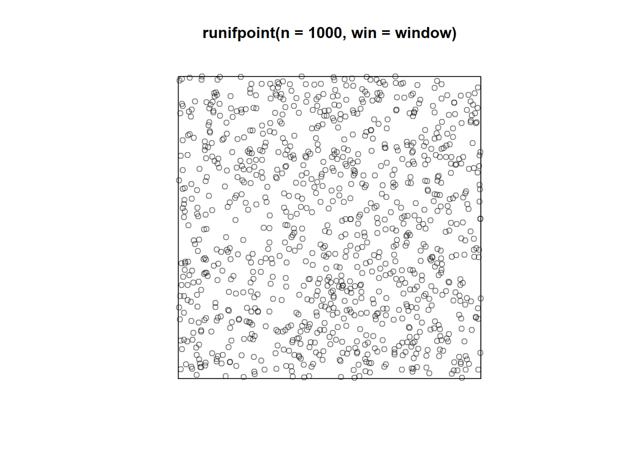

```r
# Setting up
setwd("~/R/SADE/week3")
library(rgdal)
library(raster)
library(spatstat)
library(maptools)
library(GISTools)

# Creating example data for Complete Spatial Randomness (CRS)
# Every time "plot" command is run, the pattern changes to a newly generated random distribution
window <- owin(c(0,10000), c(0,10000))
plot(runifpoint(n=1000, win=window))
```

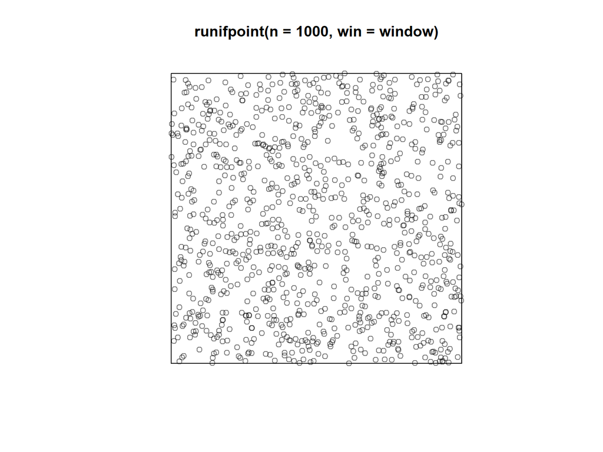

```r
# Setting seed allows everyone to see the same pattern
set.seed(1)
plot(runifpoint(n=1000, win=window))
```

```r
# Loading the study area (a 10 x 10 grid)
grid <- readOGR(dsn="grid", layer="grid")
```

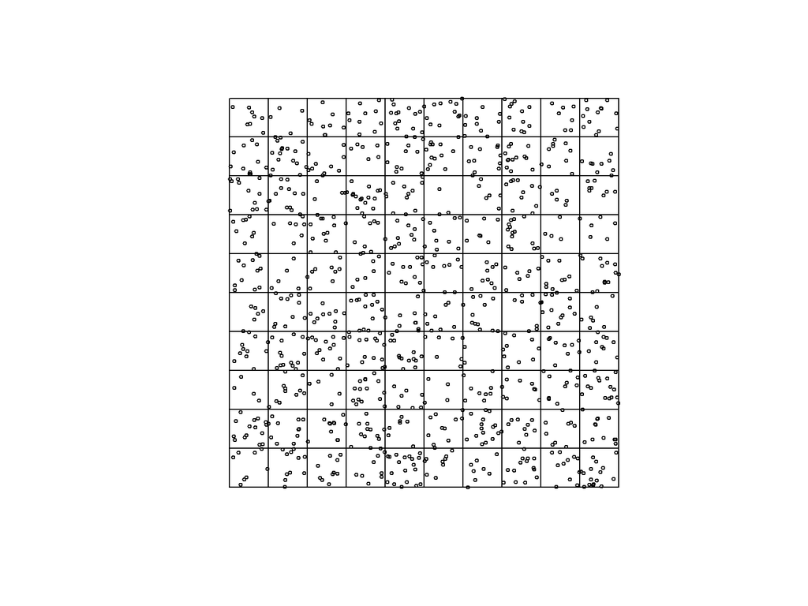

```r
plot(grid)

# Plotting the earlier random distribution to this grid illustrates that there is varying amounts of points in each cell (Poisson distribution)
set.seed(1)
randomp <- as.SpatialPoints.ppp(runifpoint(n=1000, win=grid))
crs(randomp) <- crs(proj4string(grid))
points(randomp, cex=0.5)
```

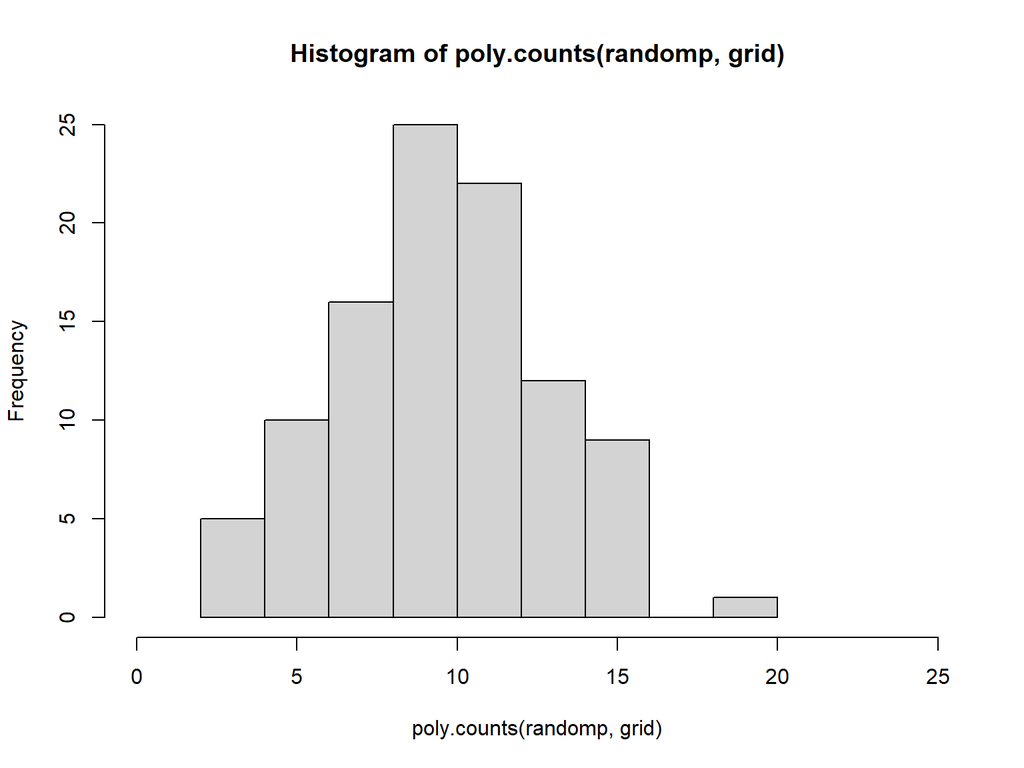

```r
# Calculating the number of points in each cell and mean value of points per cell, and plotting histogram to illustrate the distribution
hist(poly.counts(randomp,grid), xlim=c(0, 25))
```

```r
mean(poly.counts(randomp,grid))
```

```
## [1] 10
```

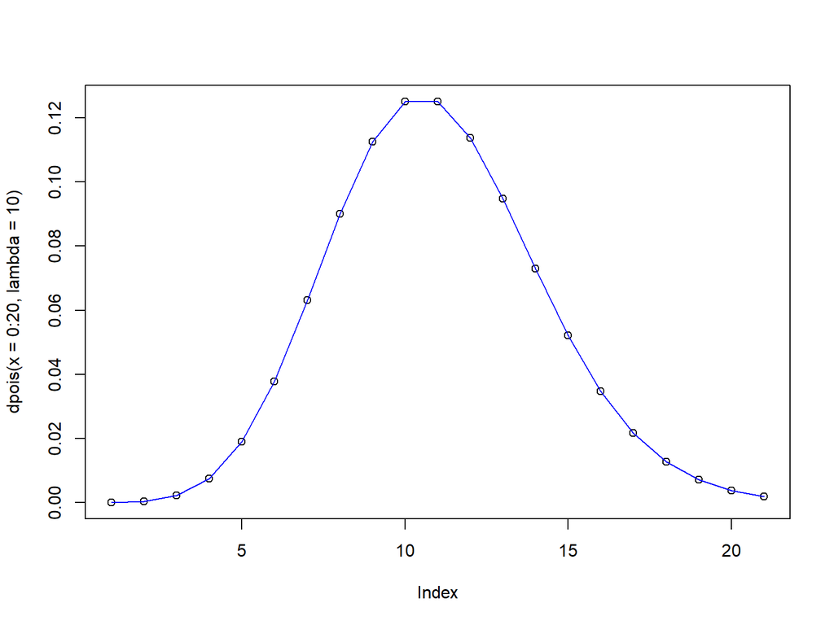

```r
# Creating a curve for idealised distribution for mean = 10
plot(dpois(x=0:20, lambda=10))
lines(dpois(x=0:20, lambda=10), col="blue")
```

## Nearest Neighbour Revisited

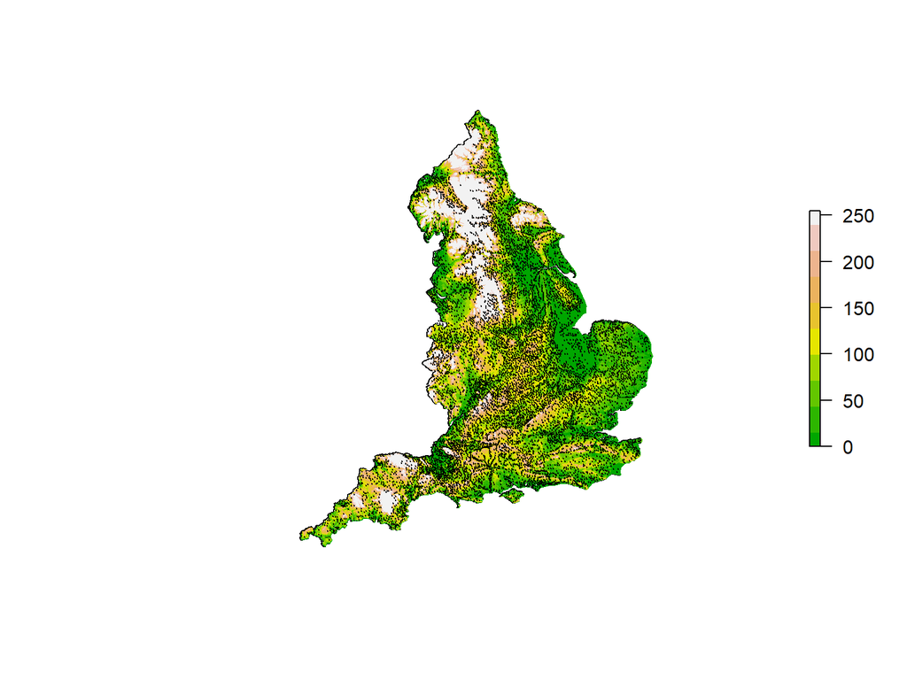

```r
# Loading the exercise data: a map depicting "nucleated" settlements (e.g. villages and towns)
polyg <- readOGR(dsn="england", layer="england_historic")
dem <- raster("dem_england/dem_england_historic.tif")
settl <- readOGR(dsn="nucleations", layer="Nucleations")
plot(polyg)
plot(dem, add=T, col=terrain.colors(10))
points(settl, pch=19, cex=0.1)
```

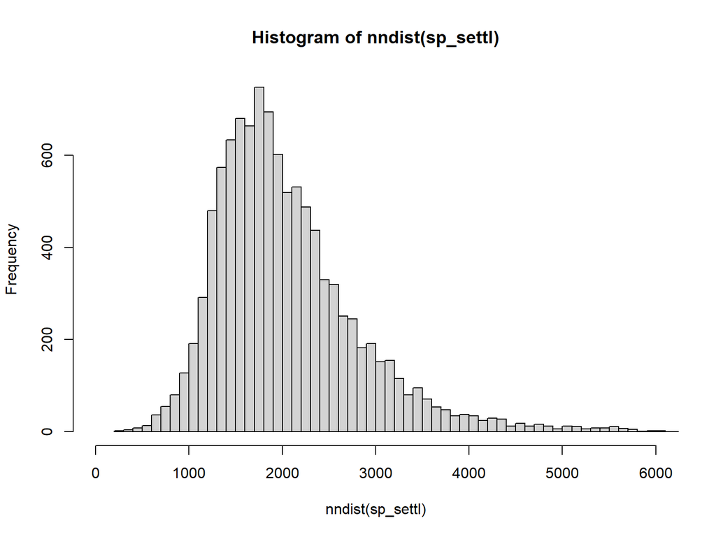

```r
# Omitting points that fall outside of the polygon and converting the data into spastat object
settl <- settl[polyg, ]
sp_settl <- as.ppp(coordinates(settl),as.owin(polyg))

# Histogram of distribution of distances and mean value
hist(nndist(sp_settl), xlim=c(0,6000), breaks=100)
```

```r
mean(nndist(sp_settl))
```

```
## [1] 2059.87
```

```r
# Clark and Evans test
# R > 1 (and p << 0.05) means that the sites are dispersed
clarkevans.test(sp_settl, corrections="all")
```

```
##
##  Clark-Evans test
##  No edge correction
##  Z-test
##
## data:  sp_settl
## R = 1.1709, p-value < 2.2e-16
## alternative hypothesis: two-sided
```

## K-function, L-function and Pair Correlation Function (PCF)

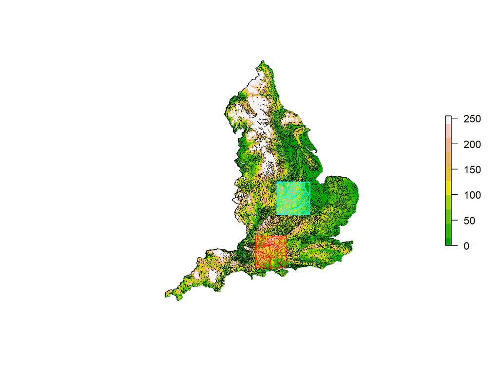

```r
# RECALLING PREVIOUS POLYGON TO THIS R CHUNK, OTHERWISE ADDING THE NEW SUBAREAS DIDN'T WORK
polyg <- readOGR(dsn="england", layer="england_historic")
dem <- raster("dem_england/dem_england_historic.tif")
settl <- readOGR(dsn="nucleations", layer="Nucleations")
plot(polyg)
plot(dem, add=T, col=terrain.colors(10))
points(settl, pch=19, cex=0.1)
settl <- settl[polyg, ]
sp_settl <- as.ppp(coordinates(settl),as.owin(polyg))

# Loading two polygons describing the new study areas
south <- readOGR(dsn="southernengland", layer="eng_south")
mid <- readOGR(dsn="midlands", layer="midlands")
plot(south, border="red", add=T)
plot(mid, border="cyan", add=T)

# Creating objects that contain settlements that fall into these regions & creating spastat objects
south_settl <- settl[south, ]
sp_south_settl <- as.ppp(coordinates(south_settl),as.owin(south))
points(sp_south_settl, pch=19, cex=0.1, col="red")

mid_settl <- settl[mid, ]
sp_mid_settl <- as.ppp(coordinates(mid_settl),as.owin(mid))
points(sp_mid_settl, pch=19, cex=0.1, col="cyan")
```

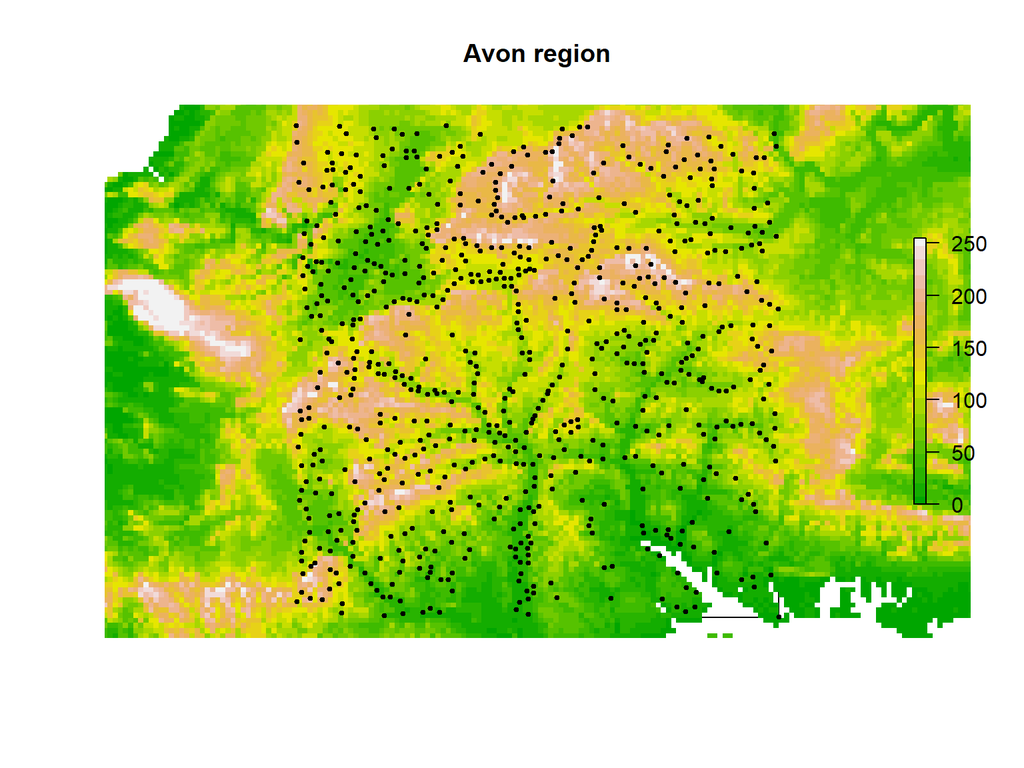

```r
# Plotting the point distributions
plot(south, main="Avon region")
plot(dem, add=T, col=terrain.colors(20))
points(sp_south_settl, pch=19, cex=0.5)
```

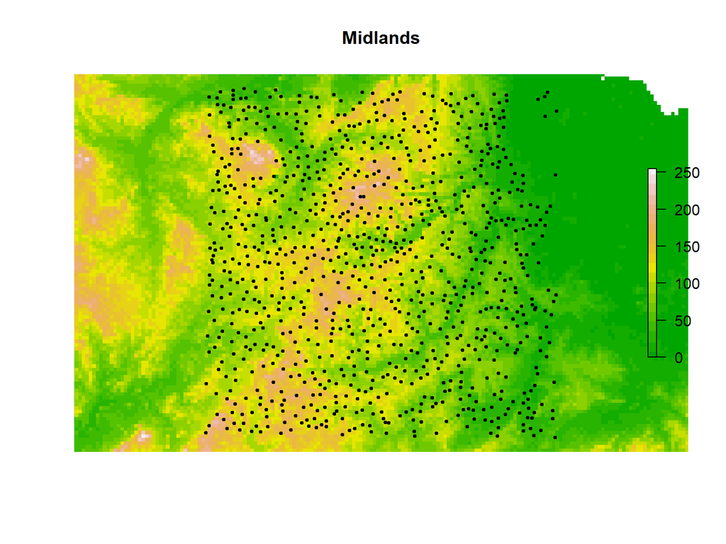

```r
plot(mid, main="Midlands")
plot(dem, add=T, col=terrain.colors(20))
points(sp_mid_settl, pch=19, cex=0.5)
```

```r
# Running Clark & Evants test
# Visually we can see that there is clustering of settlements near the waterways in "South", so the "dispersed" (R > 1) result for both of them seems not to capture the full picture
clarkevans.test(sp_south_settl, correction="none")
```

```
##
##  Clark-Evans test
##  No edge correction
##  Z-test
##
## data:  sp_south_settl
## R = 1.1343, p-value = 5.336e-12
## alternative hypothesis: two-sided
```

```r
clarkevans.test(sp_mid_settl, correction="none")
```

```
##
##  Clark-Evans test
##  No edge correction
##  Z-test
##
## data:  sp_mid_settl
## R = 1.328, p-value < 2.2e-16
## alternative hypothesis: two-sided
```

```r
# K function
# "Pois" is the expected Poisson line, the others are how the data compares to it with a few different edge corrections
k_func_south <- Kest(sp_south_settl)
dev.new(device=pdf)
plot(k_func_south, xlim=c(0,5000), main="K-Function South
close-up")

# L function (Same as K but Pois is straightened)
l_func_south <- Lest(sp_south_settl)
plot(l_func_south, xlim=c(0,5000))

# PCF (pair correlation function)
# Same principle as K, but different process ("donut rings")
# Expected Poisson is the green horizontal line
pc_func_south <- pcf(sp_south_settl)
plot(pc_func_south, xlim=c(0,5000))
```

## Monte Carlo Simulation

```r
# Monte Carlo Simulation
# The grey envelope depicts results of random point patterns simulations in the study area, the line shows where our data deviates from this area of random distribution
pc_func_100_south <- envelope(sp_south_settl, pcf, nsim=99)
```

```
## Generating 99 simulations of CSR  ...
## 1, 2, 3, 4, 5, 6, 7, 8, 9, 10, 11, 12, 13, 14, 15, 16, 17, 18, 19, 20, 21, 22, 23, 24, 25, 26, 27, 28, 29, 30, 31, 32, 33, 34, 35, 36, 37, 38, 39, 40,
## 41, 42, 43, 44, 45, 46, 47, 48, 49, 50, 51, 52, 53, 54, 55, 56, 57, 58, 59, 60, 61, 62, 63, 64, 65, 66, 67, 68, 69, 70, 71, 72, 73, 74, 75, 76, 77, 78, 79, 80,
## 81, 82, 83, 84, 85, 86, 87, 88, 89, 90, 91, 92, 93, 94, 95, 96, 97, 98,  99.
##
## Done.
```

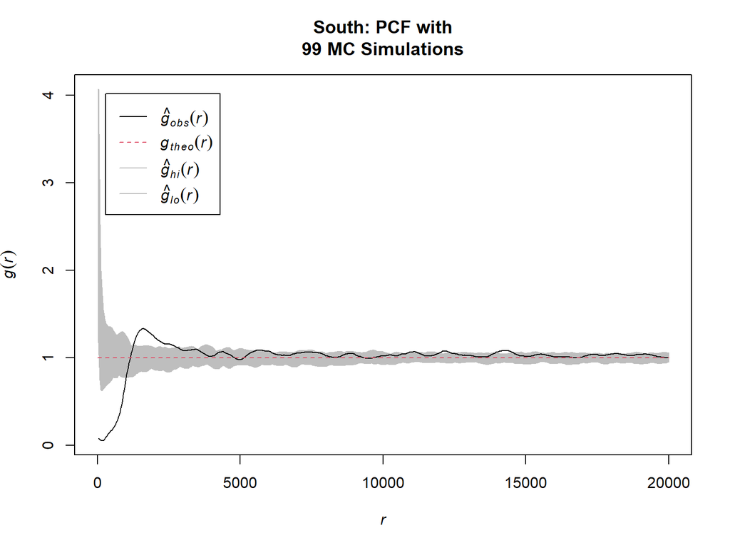

```r
plot(pc_func_100_south, xlim=c(0,20000), main="South: PCF with
99 MC Simulations")
```

```r
# Refined simulation with 999 simulations, and top and bottom 25 % removed in case of statistical outliers
# REDUCED nsim to 99 for the GitHub site as it takes too long to calculate again and again when knitting the html page
pc_func_1000_south <- envelope(sp_south_settl, pcf, nsim=99,
nrank=25)
```

```
## Generating 99 simulations of CSR  ...
## 1, 2, 3, 4, 5, 6, 7, 8, 9, 10, 11, 12, 13, 14, 15, 16, 17, 18, 19, 20, 21, 22, 23, 24, 25, 26, 27, 28, 29, 30, 31, 32, 33, 34, 35, 36, 37, 38, 39, 40,
## 41, 42, 43, 44, 45, 46, 47, 48, 49, 50, 51, 52, 53, 54, 55, 56, 57, 58, 59, 60, 61, 62, 63, 64, 65, 66, 67, 68, 69, 70, 71, 72, 73, 74, 75, 76, 77, 78, 79, 80,
## 81, 82, 83, 84, 85, 86, 87, 88, 89, 90, 91, 92, 93, 94, 95, 96, 97, 98,  99.
##
## Done.
```

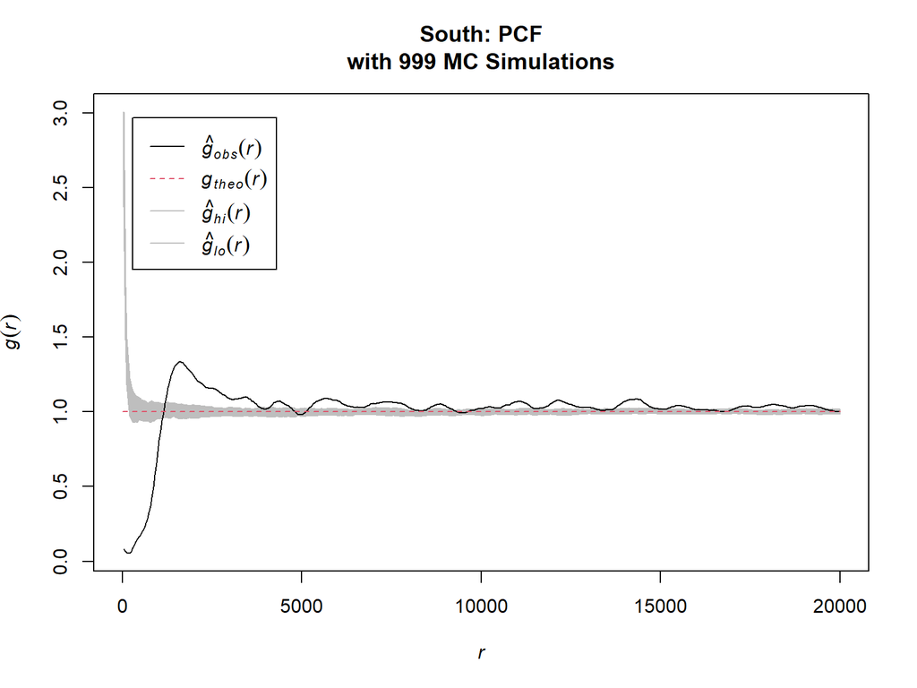

```r
plot(pc_func_1000_south, xlim=c(0,20000), main="South: PCF
with 999 MC Simulations")
```

```r
# Comparing to Midlands data: R value barely gets to random pattern envelope, settlement patterns seem to be not clustered
pc_func_1000_mid <- envelope(sp_mid_settl, pcf, nsim=99,
nrank=25)
```

```
## Generating 99 simulations of CSR  ...
## 1, 2, 3, 4, 5, 6, 7, 8, 9, 10, 11, 12, 13, 14, 15, 16, 17, 18, 19, 20, 21, 22, 23, 24, 25, 26, 27, 28, 29, 30, 31, 32, 33, 34, 35, 36, 37, 38, 39, 40,
## 41, 42, 43, 44, 45, 46, 47, 48, 49, 50, 51, 52, 53, 54, 55, 56, 57, 58, 59, 60, 61, 62, 63, 64, 65, 66, 67, 68, 69, 70, 71, 72, 73, 74, 75, 76, 77, 78, 79, 80,
## 81, 82, 83, 84, 85, 86, 87, 88, 89, 90, 91, 92, 93, 94, 95, 96, 97, 98,  99.
##
## Done.
```

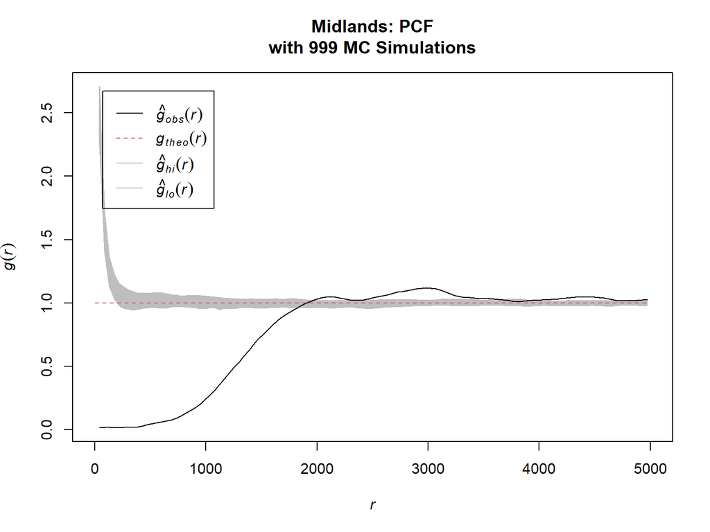

```r
plot(pc_func_1000_mid, xlim=c(0,5000), main="Midlands: PCF
with 999 MC Simulations")
```

## Linear Regression

```r
# Loading data: location of Oxford and Oxford pottery found
sites <- readOGR(dsn="pottery_sites", layer="pottery_sites")
oxford <- readOGR(dsn="oxford/oxford.shp", layer="oxford")
```

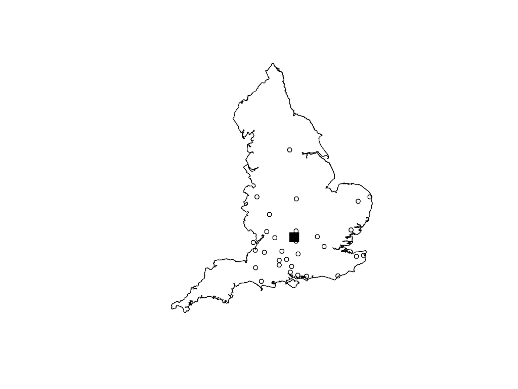

```r
plot(polyg)
points(oxford, pch=15, cex=2)
points(sites)
```

```r
# Inspecting site names
head(sites, n=30)
```

```
##               site_name oxpots id
## 1              Wroxeter   5.50  1
## 2            Droitwhich  10.75  2
## 3             Leicester   7.50  3
## 4            Gloucester  21.00  4
## 5              Caerwent  19.00  5
## 6              Gatcombe  21.00  6
## 7                  Bath  21.25  7
## 8           Cirencester  22.50  8
## 9             Alchester  22.50  9
## 10           Verulamium  17.25 10
## 11 Dorchester on Thames  22.50 11
## 12           Mildenhall  17.50 12
## 13           Silchester  19.50 13
## 14               London  18.25 14
```

[output cut: 16 more lines]

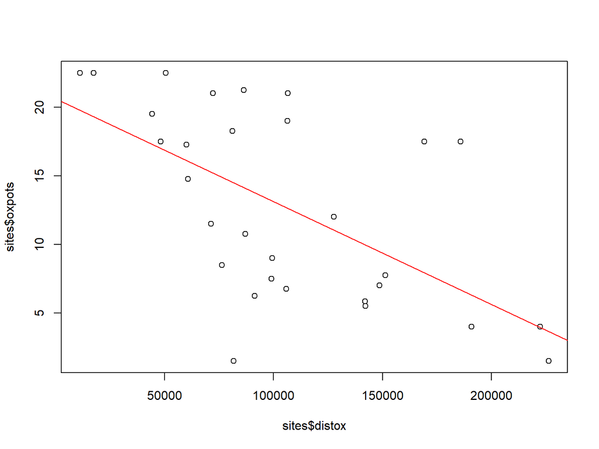

```r
# Dependant variable = the proportion of Oxford pottery at each sites (oxpots)
# Independent variable = distance of the site from Oxford

# Calculating these distances:
# Step 1: combine coordinate data to single list
coords <- rbind(coordinates(sites), coordinates(oxford))

# Step 2: distance matrix between sites
d_matrix <- as.matrix(dist(coords))

# Step 3: Adding "distox" as a column to "sites" data frame
sites$distox <- d_matrix[31,1:30]

# Scatter plot
plot(sites$distox,sites$oxpots)

# Linear regression analysis (lm) and adding the result to the scatterplot
res <- lm(sites$oxpots ~ sites$distox)
abline(res, col="red")
```

```r
# Summary of the linear regression analysis results
summary(res)
```

```
##
## Call:
## lm(formula = sites$oxpots ~ sites$distox)
##
## Residuals:
##      Min       1Q   Median       3Q      Max
## -12.9931  -4.0310  -0.6302   3.5874  10.8196
##
## Coefficients:
##                Estimate Std. Error t value Pr(>|t|)
## (Intercept)   2.061e+01  2.261e+00   9.116 7.13e-10 ***
## sites$distox -7.490e-05  1.904e-05  -3.933 0.000503 ***
## ---
## Signif. codes:  0 '***' 0.001 '**' 0.01 '*' 0.05 '.' 0.1 ' ' 1
##
## Residual standard error: 5.693 on 28 degrees of freedom
## Multiple R-squared:  0.3559, Adjusted R-squared:  0.3329
## F-statistic: 15.47 on 1 and 28 DF,  p-value: 0.0005027
```